# (Ford GoBike System Data)

## Investigation Overview

In this investigation, I wanted to look at the users characteristics like: gender, type, and age. Also look at the most popular time period. In addition to the relationship between interst features trip 'duration in minutes' and supported features 'user type' and 'member gender'.

## Dataset Overview

There are 174,952 trips in this dataset that happened in February and 1st, March of 2019. The dataset contains 16 columns that have been cleaned.

## Bike Users Types

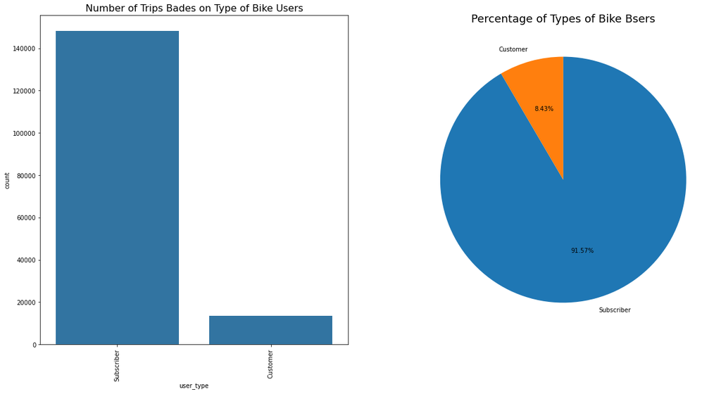

## Gender of Bike Users

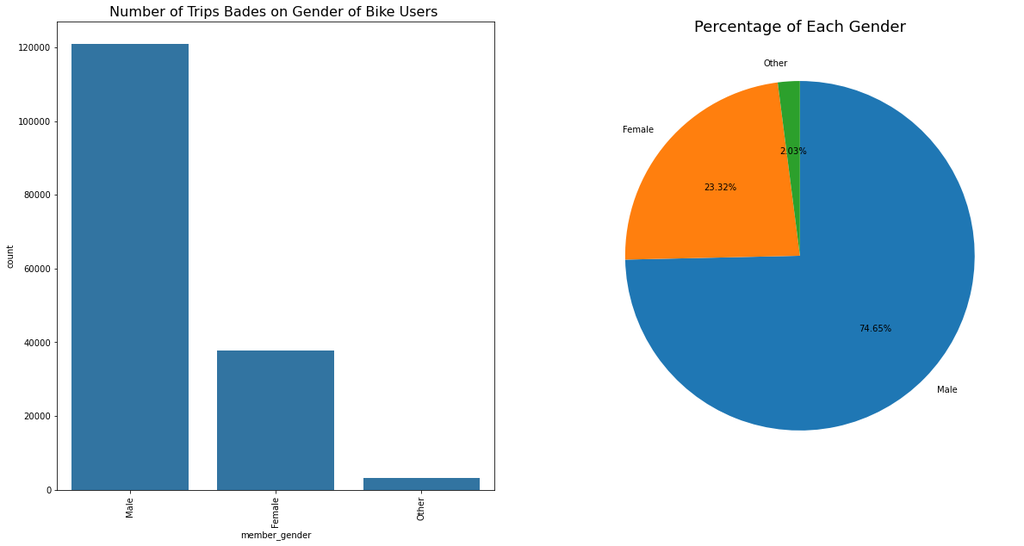

## Age of Bike Users

This distribution is skewed right and show that the median of users age is about 34 years. The boxplot show that the users age range is between 20 - 56 years.

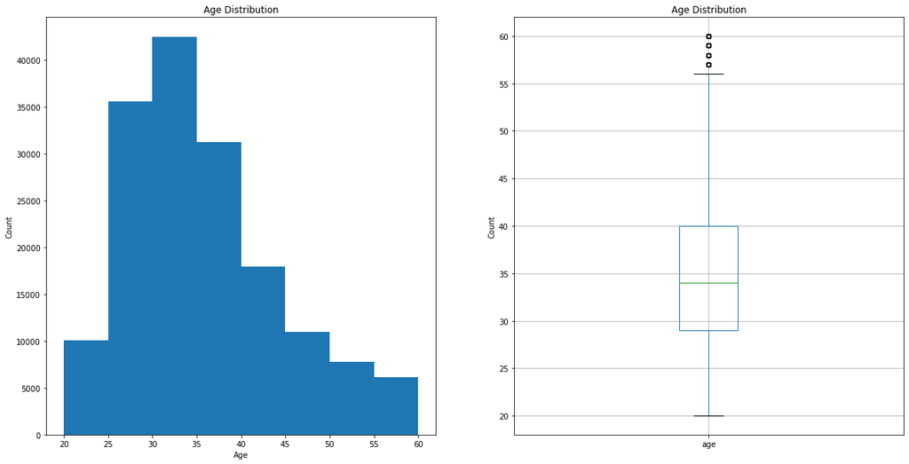

## Trips Based on Day of Week During the 24 Hours

As we notice, the popular time for trips was in weekdays not in weekends (Saturday and Sunday) and the most popular time period was from the 8 am to 9 am in the morning and from 4 pm to 6 pm in the evening in weekdays.

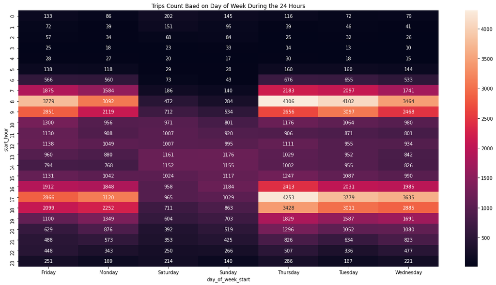

## Trips Baed on Gender Type for Each User Type

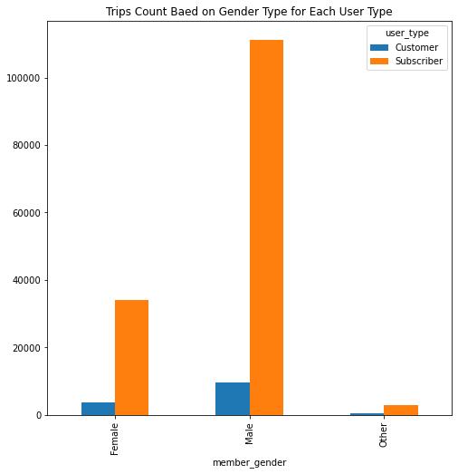

## Trips Based on Trip Duration(min) for Each User Type

The highest duration in minutes for subscriber is 5 min with about 14,000 trips and for customer is 9 min with about 1,000 trips.

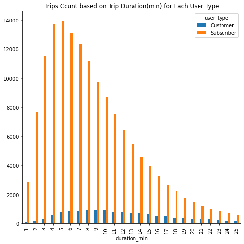

## Trips Based on Trip Duration(min) for Each User Gender

The highest duration in minutes for male is 5 min with more than 10,000 trips and for female is also 5 min with about 3,000 trips.

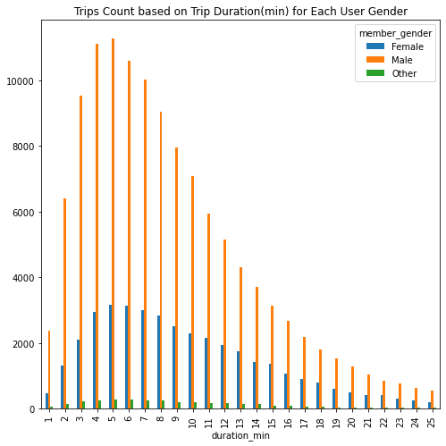

## The Median of Trips Duration in Minutes for Each User Type for Each Gender

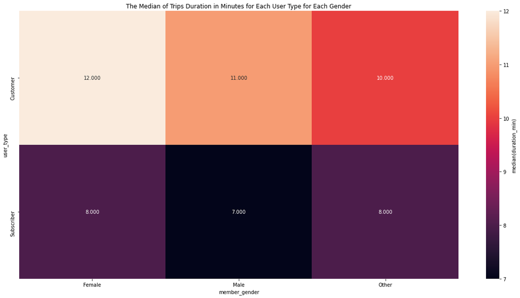